# CHAPTER C10

# 金属製桁の設計．ウェブ剪断抵抗（非座屈）型．

## パート1. 垂直補強材を有する平板シートウェブ

### C10.1 導入

フランジ部材をウェブ部材にリベット接合またはスポット溶接して構成される金属製桁の解析と設計は、航空機の構造設計において頻繁に発生する問題である。本章では、非座屈ウェブを持つ桁の一般理論を考慮する。第C11章では、桁のウェブが波打ち、準張力場状態に移行するより一般的なケースを考慮する。非座屈ウェブと座屈または準張力場ウェブの長所と短所は、第C11章で説明される。本章で提供される一般的な桁の理論は、第C11章で提供されるものの基礎となるため、学生は第C11章を学習する前に本章を研究する必要がある。

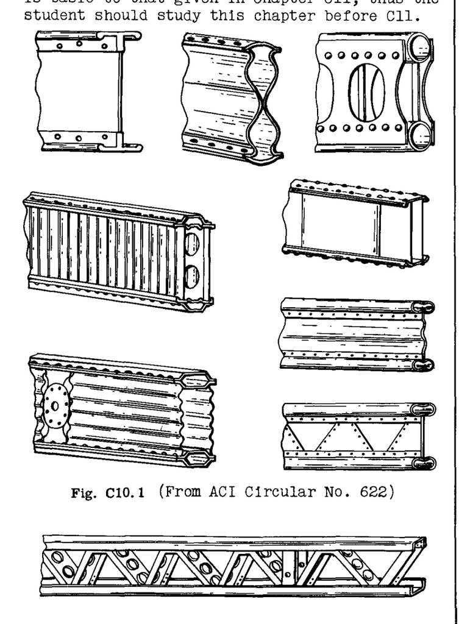

Fig. C10.1

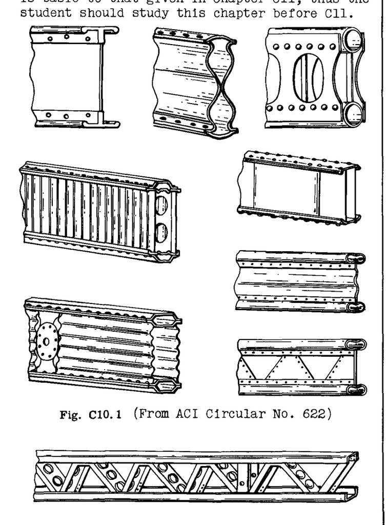

Fig. e

### C10.2 フランジ設計

強度/重量比の観点から効率を良くするためには、桁のフランジは桁断面の断面二次半径を可能な限り大きくし、同時に局所的な破壊（クリップリング）や圧潰応力が高いフランジ断面を維持するように設計されるべきである。さらに、翼の設計で頻繁に使用される大きな片持ち桁のフランジ断面は、桁が外側に延びるにつれて断面を効率的にテーパー状に減少（先細り）させることができる形状であるべきである。この断面のテーパー加工は、製造や機械加工の観点からも考慮されるべきである。強度/重量比の観点から最も効率的なフランジは、製造および組立の観点から非常に高コストであったり、完全に実用的でなかったりする場合がある。

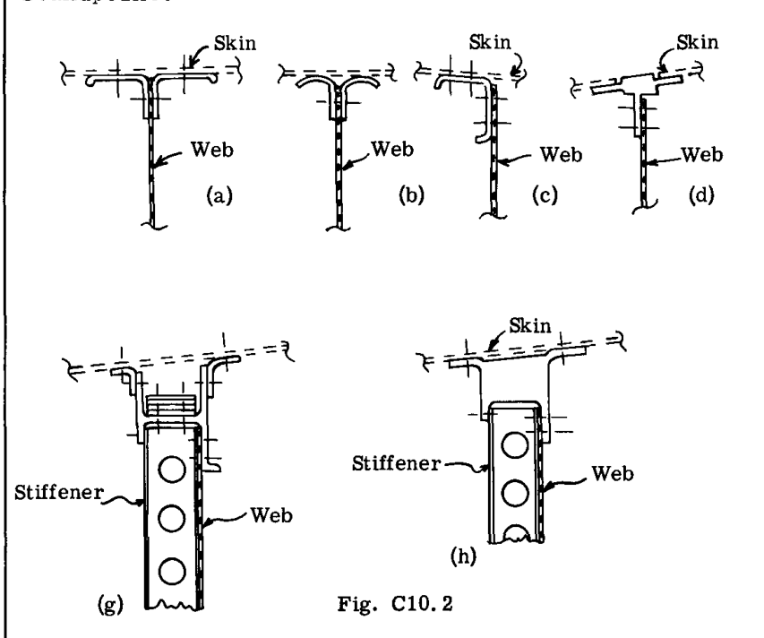

Fig. C10.2

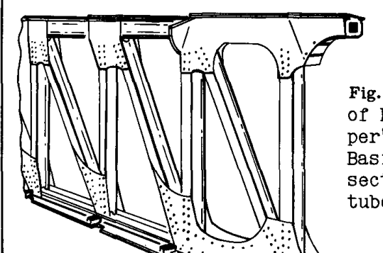

Fig. f

Fig. C10.1は、外部ブレース付きの翼における典型的な金属製桁断面をいくつか示している。このような桁は、曲げ荷重に加えて大きな軸方向圧縮荷重を支持しなければならない。Fig. C10.2は、金属外皮構造の片持ち翼に用いられる典型的な桁フランジ断面を示している。断面 (a)、(b)、(c) および (d) は、曲げ抵抗を提供するために追加のストリンガーや外皮補強材も使用される幅の広いボックス桁用の典型的な桁フランジ断面である。これらのフランジ断面は一般的に押出成形によるものであるが、(b) や (c) のような断面は板材から作成されることも多い。これらのフランジ断面は、ほぼ常に、ウェブにリベット接合またはスポット溶接された垂直補強材によって、あるいはビードやフランジ付き軽量穴によって補強された平らなシートから構成される桁ウェブとともに使用される。

Fig. (e) および (f) は、トラス桁で使用される2種類のフランジ断面を示しており、トラスウェブ部材との接続に適している。桁フランジ断面 (g) および (h) は、スパン方向の追加のストリンガーを使用しない翼構造のための典型的な断面である。断面 (g) では、まず補強板をなくし、その後、小さなアングルだけが残るまで機械加工によって押出成形形状を徐々に減少させることで、断面積のテーパー化を提供している。断面 (h) では、中央部をフライス加工してH断面を形成し、その後この断面を最終的に単純なアングルに切り落とすことによって、断面積を徐々に減少させている。

### C10.3 許容フランジ設計応力

曲げ理論において通常の仮定がなされるならば、桁フランジの応力計算は一般に難しい手順ではない。どのようなフランジ応力で破壊が起こるかという問題は、理論的な観点からは困難な問題である。設計許容値を決定する唯一の確実な方法は、特別に設計された試験桁の十分な静的試験を行うことである。

Fig. C10.1に示されるような桁断面について、設計許容応力の基礎を形成するためには、通常、以下の試験が必要である。

1. 桁に純粋な曲げを与える試験。
2. フランジの代わりにウェブで破壊が起こるような、短い長さの桁の曲げ試験。
3. 局所的な破壊（クリップリング）強度を得るための、短い長さの桁の純圧縮試験。
4. 曲げ荷重と圧縮荷重の比率を変えた、組合せ曲げ・圧縮状態におけるいくつかの桁の試験。

通常、上記の試験から、桁の設計のためのかなり完全な許容応力曲線を得るのに十分なデータが得られる。桁フランジの近似設計には、本章で示される方法を使用することができる。

Fig. C10.2の桁フランジ断面 (a)、(b)、(c) および (d) は、外皮および桁ウェブによって安定化されている。したがって、クリップリング応力を得るための短い長さの圧縮試験、および翼リブ間隔に等しい長さの試験を行うことで、設計許容値をベースにするための十分な情報が得られるはずである。トラス型桁のフランジ断面については、トラスの格点間の距離が変化するため、柱曲線を獲得するためにいくつかの長さで圧縮試験を行う必要がある。

試験桁を設計する前に、構造設計者は、提案する桁フランジ断面が応力の観点からどの程度の荷重に耐えられるかを大まかに知りたいと考える。これは、完成した構造で最終的に使用される断面に試験片を極力近づけることが望ましいためである。Fig. C10.2の断面のほとんどについて、終局応力は第C7章の方法によって概算計算することができる。Fig. C10.2の (g) や (h) のような厚肉断面において、終局応力が材料の降伏強度を大幅に上回り、かつ断面の一部が他の部分よりも先に座屈する場合や、同一フランジ断面内に2種類の異なる材料が使用されている場合、断面の終局強度を計算するための論理的な手順は、材料の応力-ひずみ線図を利用することである。

### C10.4 桁フランジ曲げ許容設計応力の計算における応力-ひずみ線図の使用

外皮上にストリンガーの形で分布させる代わりに、フランジ材料がウェブ部材の上に集中している桁型の翼構造では、発生させることができる許容終局圧縮応力は材料の降伏強度をかなり上回る。これは、フランジが厚肉要素を持つ断面で構成されていて高いクリップリング応力を促進すること、また、桁フランジはウェブおよび外皮によってそれぞれ垂直方向および水平方向に安定化されているため、柱作用の影響が無視できるからである。Fig. (a) は、このタイプの桁を示している。一般的な曲げ公式は、応力がひずみに比例すると仮定しており、これは桁材料の比例限度以下の応力に対しては正しいが、Fig. (a) のような桁のフランジに対する終局抵抗応力は比例限度をはるかに超えているため、実際の応力分布は、共通の桁理論で仮定される三角形分布ではなく、Fig. (b) の破線のようになる。したがって、比例限度を超える桁のファイバー応力を得るためには、ひずみと、そのようなひずみに伴う応力を考慮する必要があり、その関係は材料の応力-ひずみ線図から得ることができる。ひずみに対する直線分布、すなわち、曲げ後も平面は平面を維持するという仮定は妥当なものであり、試験によって検証されている。

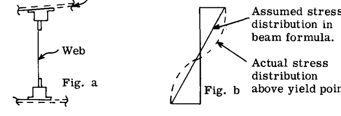

Fig. a, Fig. b

曲げを受ける桁では、片側が引張状態にあり、もう片側が圧縮状態にある。アルミニウム合金のような材料の引張および圧縮の応力-ひずみ線図は、比例限度を超えると異なり、同一の単位ひずみであっても桁の両側で異なる応力を発生させる。大型の桁の設計において頻繁にあるケースとして、桁フランジが2種類の材料で構成される場合があり、また、外皮やウェブへの取り付け用の特定の部分が、断面全体の終局強度が得られる前に座屈することがある。このような桁断面の終局内部抵抗モーメントを求めるには、桁断面を構成するさまざまな材料やユニットの応力-ひずみ線図を考慮する必要がある。桁断面の終局内部抵抗モーメントを研究する上でのこの一般的なアプローチ方法は、例題を用いて最もよく説明できる。

### 例題

Fig. C10.3は、金属外皮翼の桁の断面を示している。主フランジ部材は厚肉の24ST押出成形形状で構成されている。押出成形品は24SRTシートストリップによって補強されている。桁ウェブは24STアルクラッド材料で作られている。問題は、この桁断面の終局内部抵抗モーメントを計算することである。

平衡状態においては、中立軸より上方の全圧縮曲げ応力は、中立軸より下方の全引張曲げ応力と等しくなければならない。

となる。Fig. C10.3に示される幾何学的中立軸まわりの特性を持ち、Fig. C10.5aのひずみ図による応力に対応する、46000 psiおよび52000 psiの外側ファイバー応力を用いた通常の桁公式を使用すると、内部抵抗モーメントは、

$$M = \frac{f I}{c} = \frac{46000 \times 436}{9.69} = 2070000 \text{ in. lb.}$$

に等しくなり、より論理的な解法による2392000 in. lb.と比較して16パーセントの差が生じる。もし突出脚(a)が座屈しないとすれば、より正確な解ではこの要素に対して35000 psiのみを許容しているのに対し、一般的な桁公式では46000 psiの応力を受けることになるため、不一致はさらに大きくなる。

### 試行錯誤によるアプローチ

中立軸の位置は未知であるため、Table C10.1およびC10.2における計算は、中立軸の真の位置であるという最終的な仮定に対するものである。一般的な手順は次のようになる。中立軸を桁のセンターライン軸と仮定し、軸の各側の全軸方向荷重を求める。通常、結果は一方のフランジに過剰な荷重を示す。次の試行のために、中立軸を移動させて、もう一方のフランジに過剰な荷重が生じるようにする。Fig. C10.5bに示されるように結果をプロットして中立軸の真の位置を得て、その後、Table C10.1およびC10.2に示されるように最終計算を行う。

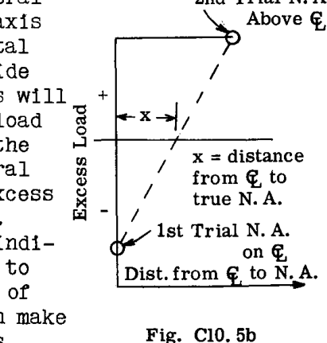

Fig. C10.5b

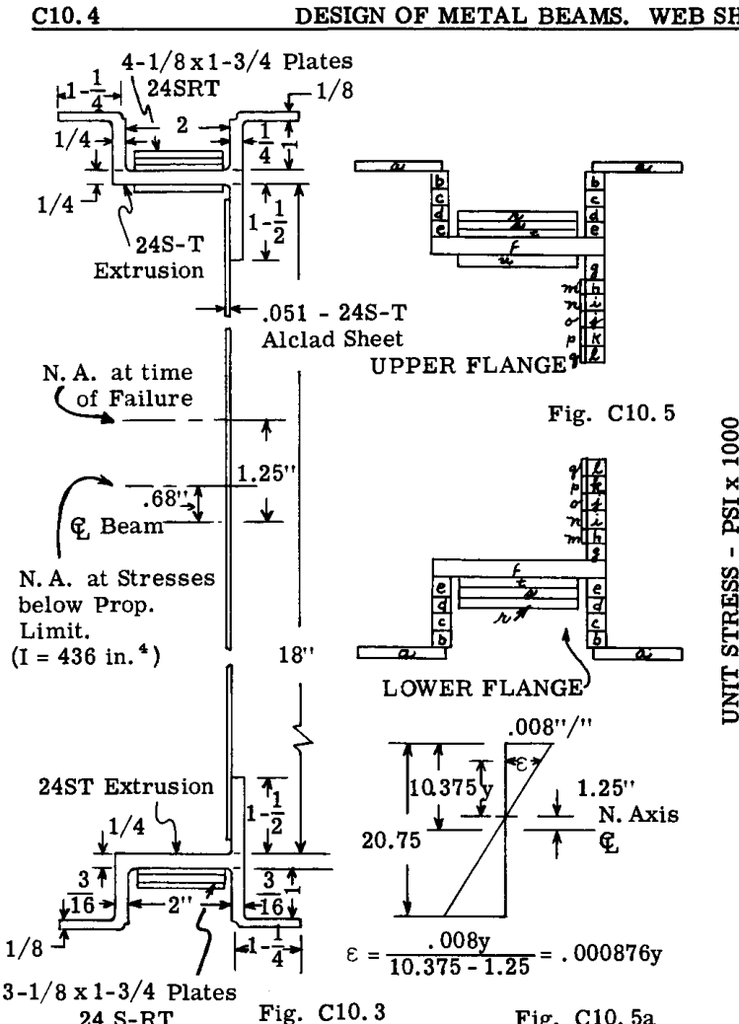

Fig. C10.5, Fig. C10.3, Fig. C10.5a

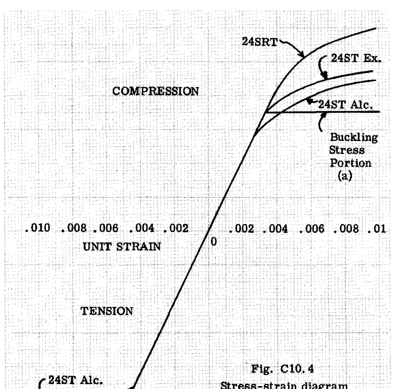

Fig. C10.4

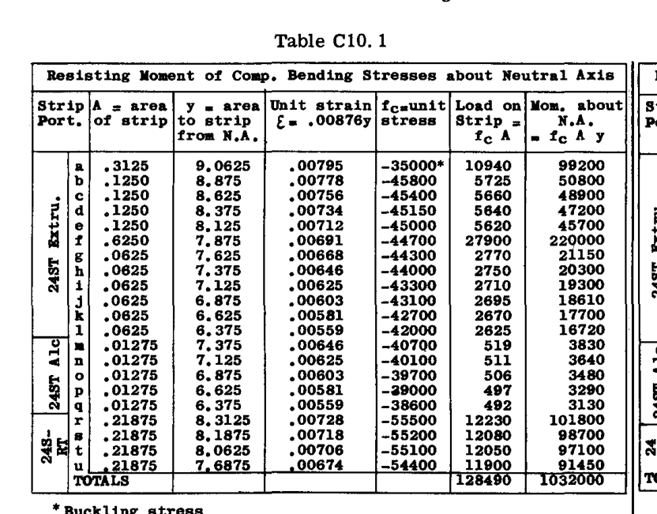

Table C10.1

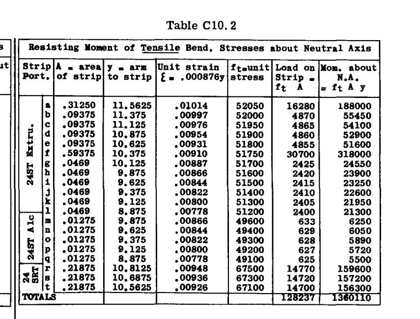

Table C10.2

### C10.5 フランジ強度（クリップリング）

桁設計の多くの場合、フランジはセル構造の一部であるため側方向にブレースされており、桁フランジに固定されたシートカバーがフランジに連続的な側方向ブレースを提供するか、桁フランジの側方向曲げ座屈作用を防止する。桁ウェブはウェブ方向のフランジの柱曲げを防止するため、フランジは局所的なクリップリング作用によって破壊し、クリップリング応力は第C7章の方法によって決定される。多くの場合、桁の荷重は比較的小さく、したがってフランジに必要な面積は比較的小さい。これは、要素の厚さが小さいフランジ形状であることを意味し、したがって破壊時の局所強度は弾性応力範囲内であるか、または比較的低いものとなる。

多くのケース、たとえば胴体フレームなどでは、フレーム断面の内側フランジは側方向のブレースから自由であるため、フランジを側方向にブレースするための対策を講じるか、フランジを側方向の柱作用に対して設計しなければならない。この主題については、第D3章でさらに詳しく説明する。

### C10.6 ウェブ強度。安定ウェブ。

安定ウェブ桁とは、ウェブが座屈することなく設計荷重を支持するもの、言い換えれば、初期の平坦な状態を維持するものである。設計剪断応力は、個々のウェブパネルの座屈剪断応力以下であり、ウェブ補強材は、ウェブ全体としての座屈を防止するのに十分な剛性を有している。

一般に、非座屈用に設計されたウェブ補強材を持つ薄肉ウェブ桁は、強度/重量比が比較的悪いため、飛行中の乗り物構造には広く使用されていない。インテグラル燃料タンクなどでは、リベットで接合されたウェブパネル境界に沿った漏れをより確実に防止するために、設計荷重下で桁ウェブやスキンが座屈や波打ちを起こさないことが望ましい場合が多い。

学生は、ウェブの座屈応力が破壊応力ではないことを理解すべきである。ウェブは、崩壊が起こる前により多くの荷重を受けることができるため、一般にウェブは荷重を負担するための全容量までロードされておらず、ウェブ補強材はウェブの座屈を防止するのに十分な剛性のみを目的として設計されており、ウェブの完全な破壊強度のために設計されているわけではない。

### ウェブ座屈剪断応力の公式

である。この方程式を解くには、第C5章のFig. C5.13およびC5.11の曲線が使用され、読者は剪断荷重下のシート座屈の確認のために第C5章のArt. C5.8を参照されたい。

### ウェブ座屈曲げ応力の公式

ウェブが座屈しない場合、ウェブは、桁中立軸で応力がゼロとなる圧縮および引張の縦方向曲げ応力を受ける。したがって、一般に、桁は組合せ剪断および曲げ応力システムを受ける。

である。この方程式を解く際には、第C5章のFigs. C5.15およびC5.8が使用される。

### 組合せ剪断および曲げの下でのウェブパネルの座屈

第C5章のArt. C5.11から、組合せ曲げおよび剪断下の平板シートパネルに対する相互作用方程式は、

$$R_b^2 + R_s^2 = 1 \quad \cdots \text{(C10.3)}$$

である。安全余裕（M.S.）の表現は、

$$\text{M.S.} = \frac{1}{\sqrt{R_b^2 + R_s^2}} - 1 \quad \cdots \text{(C10.4)}$$

である。

### C10.7 ウェブの曲げおよび剪断応力

ウェブは設計荷重下で座屈しないように設計されているため、ウェブは曲げ応力を受けるのに有効であり、以下のよく知られた方程式が適用される。

$$f_b = \frac{M y}{I_x} \quad \cdots \text{(C10.5)}$$

ここで、 $I_x$ はウェブを含めた桁断面の断面二次モーメントである。

第A14章のArt. A14.3において、よく知られた撓み剪断応力方程式が導出された、すなわち、

$$f_s = \frac{V}{I b} \int y dA \quad \cdots \text{(C10.5)}$$

である。 $\int y dA$ の項は中立軸における断面で最大となるため、桁の剪断応力は中立軸で最大となる。一般に、航空機桁のウェブは比較的薄いため、ウェブに対する $\int y dA$ の項は非常に小さく、ウェブ全体の剪断応力強度はほぼ一様である。したがって、最大ウェブ剪断応力を計算するために、単純な公式 $f_s = V / hb$ が広く使用されてきた。この方程式において、 $h$ は剪断応力 $f_s$ が式C10.5で与えられる剪断応力の最大値と一致するような距離である。

曲げおよび剪断状態にある桁から切り取られた微小要素における内部応力を単純に考慮することで、簡略化された剪断方程式 $f_s = V / hb$ で使用する $h$ の値が示される。

Fig. C10.6aは、曲げモーメントを受ける桁から切り取られた長さ $dx$ の桁要素を示しており、これにより上部で圧縮が生じる。断面(AB)における曲げモーメントは $M$ であり、断面(CD)における曲げモーメントは $M + \Delta M$ であるため、面(CD)における応力を表すベクトルは面(AB)におけるものよりも長く描かれている。桁要素はまた、各面に全剪断力 $V$ を受ける。 $C_2$ および $C_1$ は、各面における全圧縮力の合力を表し、 $T_2$ および $T_1$ は引張応力の合力を表す。Fig. (b)は、同一の自由体を示すが、各面における引張および圧縮応力が、Fig. (a)のシステムと同じ結果でブロックを動かそうとする単純な力 $C$ および $T$ に置き換えられている。Fig. (c)において、Fig. (b)の桁要素は中立軸に沿って切断されており、切断面には $f_s b dx$ に等しい力が加えられている。ここで、 $f_s$ は水平剪断応力強度に等しい。

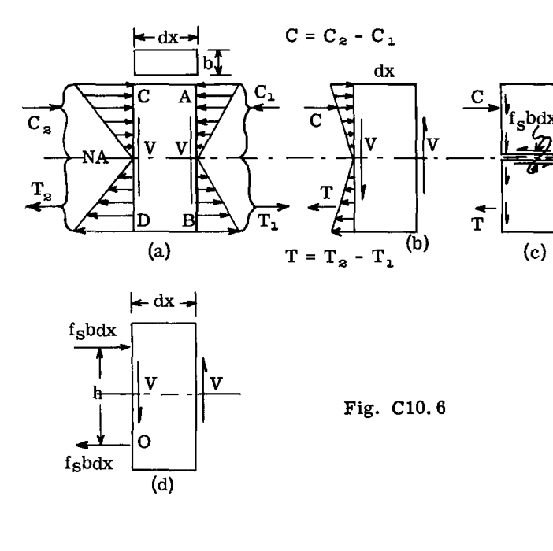

Fig. C10.6

上部における水平力の和がゼロでなければならないという平衡方程式を書くと、以下を得る。

$$C - f_s b dx = 0 \quad \text{したがって} \quad C = f_s b dx$$

そして同様に下部に対しては、

$$T + f_s b dx = 0 \quad \text{したがって} \quad T = f_s b dx$$

である。

Fig. (d)は、Fig. (b)の自由体を示すが、 $C$ および $T$ がそれらの上記の等価な値に置き換えられている。

点(O)まわりのモーメントをとると、

$$M_O = f_s b dx \cdot h - V dx = 0 \quad \text{したがって}$$

$$f_s = \frac{V}{b h} \quad \cdots \text{(C10.6)}$$

となる。したがって、方程式(a)で与えられる最大値に等しい応力値 $f_s$ を得るためには、曲げ応力の図心間の距離に等しい有効アーム( $h$ )を使用する。矩形断面の場合、有効アームは明らかに桁高さの2/3に等しいが、Fig. C10.11やC10.12に示されるような一般的な桁断面の場合、特にウェブが曲げにおいて有効であると考慮される場合、曲げ応力の図心間の距離はそれほど明らかではない。有効アーム( $h$ )の近い近似、および一般的な手法として行われている手順は、( $h$ )をウェブ-フランジリベットの図心間の距離に等しいと仮定することである。学生は、いくつかの例題桁断面を取り、Eq. (C10.6)を使用した( $h$ )に対するこの仮定を、Eq. (C10.5)による正確な値に対してチェックすべきである。

一部の構造設計者は、桁ウェブによって負担される全垂直桁剪断力の割合について仮定を立てる。たとえば、ウェブが桁剪断全体のすべてを負担すると仮定されることもあれば、90パーセントだけを負担すると仮定されることもある。ウェブによって負担される剪断荷重の割合は、当然、フランジ断面のサイズおよびウェブ断面の形状に依存する。たとえば、Fig. C10.7において、同一のフランジが、Figs. (a)および(b)に示される2つの方法でフランジに取り付けられたウェブによって接続されている。Fig. (a)では、部分(AB)および(CD)上の剪断流が外部剪断への抵抗を助けるのに対し、Fig. (b)におけるこれらの部分上の剪断流は、外部剪断荷重と同一方向に作用するため、ウェブ上の剪断荷重を外部剪断荷重よりも大きくする（開断面および閉断面における剪断流の一般的な議論については、第A14章およびA15章を参照されたい）。

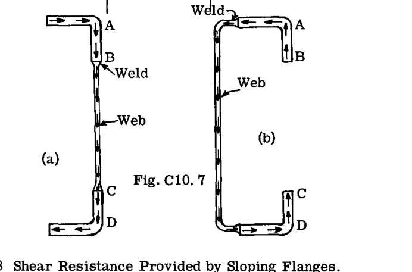

Fig. C10.7

### C10.8 傾斜フランジによって提供される剪断抵抗

航空機の翼および尾翼表面における桁の大部分は、平らな形状および厚さの両方における構造のテーパー化のため、傾斜したフランジを持っている。この桁フランジの傾斜は、ウェブが負担する剪断荷重を軽減させるものであり、無視すべきではない。Fig. C10.8は、荷重システム $P_1$ 、 $P_2$ などを支持する桁(abcd)を示している。上部フランジは示されるように傾斜している。もし両方のフランジが延長された場合、それらは点(O)で交差する。

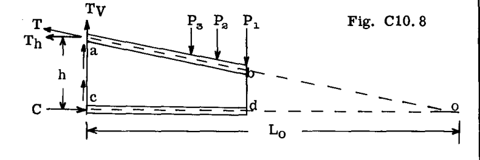

Fig. C10.8

断面(ac)における曲げモーメントを $M$ とする。

すると、

$$C = T_h = \frac{M}{h} \quad (h = \text{フランジ応力図心間の距離})$$

となる。

上部フランジにおける荷重 $T$ の垂直成分 $T_v$ は $T_h h / L_O$ に等しいが、 $T_h = M / h$ であるため、したがって、

$$T_v = \frac{M}{h} \frac{h}{L_O} = \frac{M}{L_O}$$

となる。 $V_F$ を桁フランジによって負担される剪断荷重とする。

すると、

$$V_F = \frac{M}{L_O} \quad \cdots \text{(C10.7)}$$

となる。したがって、傾斜したフランジ部材の軸方向荷重によって負担される剪断成分は、考慮されている断面における曲げモーメントを、断面からフランジの交点(O)までの距離で割ったものに等しくなる。

上記の導出は、全抵抗モーメント $M$ がフランジによって発生されるという仮定に基づいていた。ウェブが曲げにおいて有効である場合、ウェブによって発生されるモーメントを全曲げモーメント $M$ から差し引くべきである。

$$I = I_{Fl.} + I_{Web}$$

とおく。

ウェブによって発生されるモーメントは、

$$M \frac{I_{Web}}{I}$$

である。ここで、 $M$ は断面における全曲げモーメントである。

航空機構造において、傾斜フランジ部材を持つ片持ち桁は一般的なケースであり、フランジ軸方向荷重による剪断抵抗は、強度-重量の観点から効率的な構造が望まれる場合には無視すべきではない重要な要因である。

### C10.9 撓み剪断応力分布に対する可変断面二次モーメントの影響

第A14章で導出された基本的な剪断応力方程式 C10.5 は、厳密には一定の断面二次モーメントを持つ桁に適用される。航空機桁の場合、一般的なケースは可変の断面二次モーメントを持つものである。したがって、方程式 C10.5 によって得られる応力は不正確であるが、ほとんどのケースにおける不一致は大きくない。学生は、テーパー翼構造における剪断流の図を研究する際に、この事実を理解すべきである。第A15章のArt. A15.15を参照されたい。

### C10.9a フランジの不連続性

重量節約の観点から、加えられる荷重に対して等強度桁に近づけるためには、フランジ断面をテーパー状にすることが必要である。

Fig. a は、このようなフランジ断面のテーパー化が、局所的な偏心フランジ荷重を発生させる様子を示している。断面(1)と(2)の間で、上部フランジは側面図において示されるようにテーパー状になっており、これにより示されるようにフランジ中立軸が変位する。示されるように桁部分にわたって曲げモーメントの変化がないと仮定すると、抵抗アーム $d$ が $d_1$ よりも小さいため、力 $F$ は $F_1$ よりも大きくなければならない。平衡状態においては、 $F_1$ と $F$ が同一直線上にないことによるこのモーメントは、何らかの方法でバランスされなければならない。もしフランジがウェブおよび補強材に剛に接続されている場合、このモーメントは、Fig. b に示されるように、点(1, 2, 3 および 4)の間のウェブパネル上の追加の剪断応力によってバランスさせることができる。したがって、偏心を発生させるようなフランジ断面のかなり急激な変化があるケースにおいては、ウェブ上の追加の剪断流荷重に対してウェブおよび補強材をチェックすべきである。もしフランジ中立軸におけるこのような変位が平面図において発生する場合、追加の剪断応力に対して外皮カバーを調査すべきである。

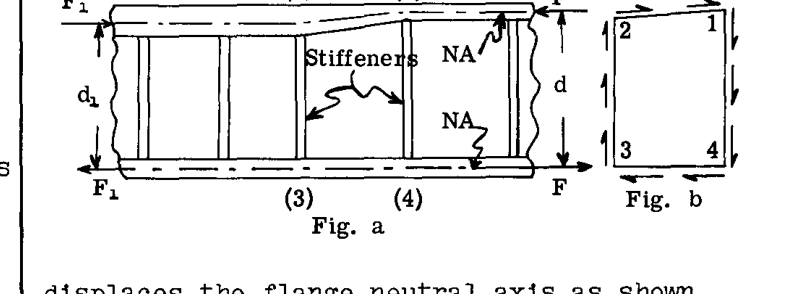

Fig. a, Fig. b

### C10.10 非座屈ウェブで使用する補強材のサイズ

ウェブ補強材は、ウェブパネルのサイズを減少させるために使用される。したがって、ウェブの座屈が開始すると、補強材は座屈が補強材を横切って広がるのを防ぐ傾向があるか、またはシートを1つではなく2つのパネルで座屈させる。H. Wagner氏は1930年のA.S.M.E.の会議で発表された論文において、剪断抵抗ウェブとともに使用される補強材の必要な断面二次モーメントとして以下の式を提案した。

$$I_V = \frac{2.29 d}{t} \left( \frac{V h_w^4}{33 E} \right)^{1/3} \quad \cdots \text{(C10.8)}$$

ここで、

- $I_V$ = 補強材の断面二次モーメント
- $d$ = 補強材間のセンターライン距離
- $h_w$ = ウェブプレートの深さ
- $V$ = 断面における垂直剪断力
- $t$ = ウェブ厚さ
- $E$ = 縦弾性係数

平坦および湾曲ウェブの両方に対する補強材剛性( $I_V$ )のより最近の基準が、Fig. C10.9の曲線によって与えられている。補強材が単に補強材として使用され、集中した外部荷重をウェブに伝達する手段として使用されない場合、補強材をウェブに取り付けるのに必要な最小のファスナー数はいくつかという疑問が生じる。非座屈ウェブに対しては、2つの基準が提案されている。

1. 補強材は各端部でフランジに取り付けられるべきである。
2. リベットピッチ（間隔）は、（文献1）によれば、ウェブパネルの端部における単純支持の仮定を正当化するために、せいぜい補強材間隔の1/4倍、またはこれが小さい場合はウェブ高さの1/4に等しくあるべきである。通常のプラクティスでは、より多くのリベットを使用する。

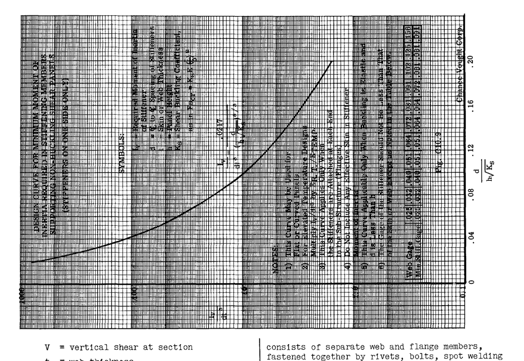

Fig. C10.9

### C10.11 桁リベット設計に関するメモ

一体成形として押出成形される非常に小さな桁断面を除いて、通常の桁は、リベット、ボルト、スポット溶接または連続溶接によって互いに固定された、分離されたウェブおよびフランジ部材から構成される。このような桁の設計においては、適切な接続強度を提供するために、リベット、ボルトなどがどのような荷重を受けるかを知ることが必要である。単純な公式に代入して桁フランジリベット上の荷重を求めることは非常に容易であるが、学生は、これらの公式の背後にある基本的な桁作用を確実に理解すべきである。

Fig. C10.10は、フランジリベットピッチ $p$ に等しい長さの桁部分を示している。断面(AA’)における桁断面は、曲げモーメント $M$ および断面(CC’)における $M + \Delta M$ を受ける。桁面における曲げ応力分布は応力三角形によって示されている。この例の断面においては、ウェブは曲げ応力を負担しないと仮定される。

曲げモーメント $M$ による断面ABにおけるフランジ角への全引張力を $P_F$ とする。すると、断面CC’におけるモーメント $M + \Delta M$ による断面CDにおけるフランジ角への全引張力は $P_F + \Delta P_F$ に等しくなる。

これらの2つの力の作用下で、フランジ角は左に移動しようとするが、この移動はフランジ角をウェブに結合するリベットによって防止される。したがって、リベット上の荷重は $\Delta P_F$ に等しくなる。下部フランジ角をウェブに保持するリベットに対しても、同様の推論が適用される。

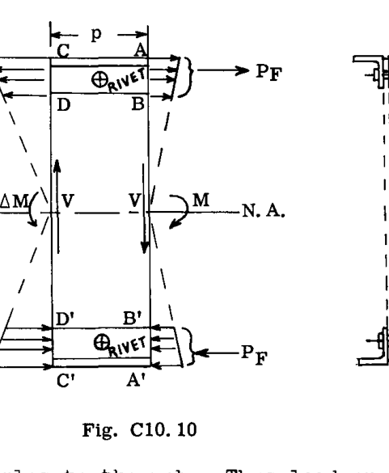

Fig. C10.10

Fig. C10.10の桁部分全体は、曲げ応力および各面における剪断荷重 $V$ の下で平衡状態にある。

下部フランジ曲げ荷重と桁面CC’の交点まわりのモーメントをとると、

$$\left[ P_F - (P_F + \Delta P_F) \right] h' + V p = 0 \quad \cdots \text{(C10.9)}$$

したがって、

$$\Delta P_F = \frac{V p}{h'} \quad \cdots \text{(C10.10)}$$

となる。

方程式 C10.10 は、距離 $p$ におけるフランジ軸方向荷重の変化は、桁上の垂直剪断力にリベットピッチ $p$ を掛け、フランジ曲げ応力図心間の距離で割ったものに等しいことを示している。 $\Delta P_F$ はまた、長さ $p$ にわたってフランジ角によって発生される水平剪断流でもある。フランジによる1インチあたりの水平剪断力( $q$ )は、

$$q = \frac{V}{h'} \quad \cdots \text{(C10.11)}$$

となる。

剪断流の一般的な表現（第A14章を参照）は、

$$q = \frac{V}{I} \int y dA \quad \cdots \text{(C10.12)}$$

である。

Eq. (C10.11) は、Eq. (C10.12) の $I$ および $\int y dA$ の項が必要なく、距離 $h'$ を計算なしで綿密に見積もることができ、フランジ面積の図心間の距離よりも大きくなるため、使用が容易である。

方程式 (C10.11) は、桁ウェブが曲げ応力を負担しないという仮定の下で導出された。一般に、これは真ではないか、または部分的にのみ真である。ウェブが曲げを負担する場合、モーメント中心まわりのウェブ上の曲げ応力のモーメントが含まれていないため、方程式 (C10.9) は誤りとなる。したがって、簡略化された方程式 (C10.11) を作成し、方程式 (C10.12) によって与えられる正確な結果をチェックするには、距離( $h$ )がフランジ応力図心間の距離よりも大きくなければならない。実際、( $h$ )を桁高さに等しいとすることは、方程式 (C10.12) の結果から遠くない。

### C10.12 フランジ部材に補強板を取り付けるリベット上の荷重

桁フランジは、一般的に、リベットまたはスポット溶接によってメインユニットに保持されたメインユニットに加えていくつかの補強板または部品から構成される。Fig. C10.11は、典型的な桁フランジを示している。上部フランジの基本断面は板(a)および(b)によって補強され、下部フランジは板(c)および(d)によって補強されている。リベットの目的は、桁の曲げによって補強板がフランジT字断面に沿って滑るのを防ぎ、それによって板を曲げにおいて有効にすることである。補強板を滑らせようとするこの水平力、およびリベットによって剪断において防止される力は、基本的な剪断流方程式 (C10.12)、すなわち、

$$q = \frac{V}{I} \int y dA$$

によって与えられ、これは桁に沿った1インチあたりの水平剪断力に等しい。Fig. C10.11の上部フランジのリベットセクション1-1における荷重を求めるには、 $\int y dA$ の項は、板(a)の面積に、その図心から中立軸までの距離を掛けたものに等しい。セクション(2-2)におけるリベット上の剪断荷重に対しては、 $\int y dA$ の項は、板(b)の面積に中立軸までの距離を掛けたものに等しい。下部フランジリベットセクション(3-3)においては、両方の補強板が同一側にあるため、臨界状態であり、板(c)および(d)によって発生される全剪断流はリベットセクション(3-3)によって抵抗されなければならない。したがって、 $\int y dA$ の項は、両方の板の面積に桁の中立軸までの距離を掛けたものに等しくなる。

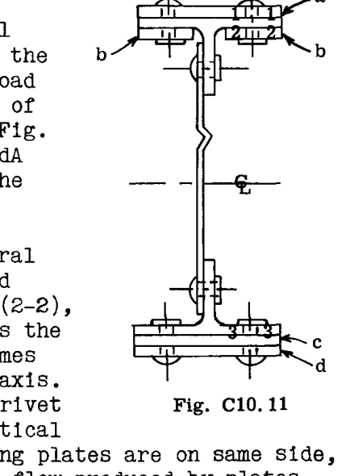

Fig. C10.11

良好な結果をもたらす簡略化された方法は、全フランジのユニットの相対面積に基づいている。フランジの桁ウェブへの接続を設計するには、全フランジによって発生される全水平剪断 $q$ が常に必要であり、剪断流計算における全フランジ面積の使用、

$$q = \frac{V}{I} \int y dA$$

を伴う。

補強板によって発生される剪断流は、全フランジ面積に対する板の面積の割合に全フランジ剪断流を掛けたものに比例すると仮定される。簡略化された方程式 (C10.11) を使用すると、以下のように書くことができる。

$$q = \frac{V}{h'} \frac{a_p}{A_F} \quad \cdots \text{(C10.13)}$$

ここで、

- $a_p$ = 考慮している板の面積
- $A_F$ = フランジの全面積
- $q$ = リベット上の1インチあたりの荷重
- $V$ および $h'$ = 前に説明した通り

傾斜フランジを持つ桁におけるリベット荷重に対して、剪断 $V$ は、ウェブ剪断応力を議論する際に前に説明した正味の剪断力である。

### C10.13 ウェブスプライス

通常、板桁を設計する場合、重量節約の観点から、いくつかのウェブシート厚さを使用することが必要であり、これはウェブスプライスを意味する。Fig. C10.12は、典型的なウェブスプライスを示している。Fig. (a)は、Fig. (b)のケースのようにウェブのジョグリングを防止する、比較的厚いウェブに対して典型的である。Fig. (b)のケースでは、重ね合わせは通常、薄いウェブシートにリベットを打ち込む際にウェブをサポートするウェブ補強材の下で行われる。

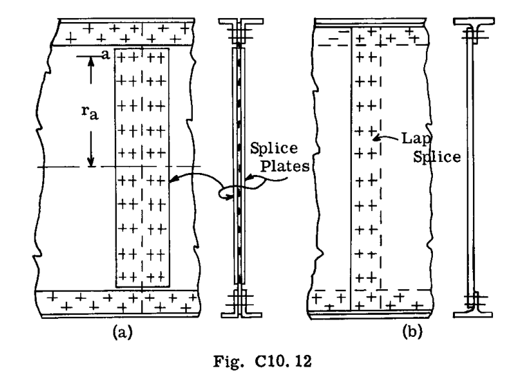

Fig. C10.12

### ウェブスプライスリベット上の荷重

ウェブは剪断荷重を受け、安定ウェブに対しては、ウェブは曲げ応力を受ける。

リベット設計においては、通常、ウェブ剪断応力は深さにわたって一定であると仮定される。したがって、各ウェブスプライスリベット上の荷重の垂直成分は同じであり、

$$R_v = \frac{V}{n} \quad \cdots \text{(C10.14)}$$

ここで、

- $V$ = 正味のウェブ剪断
- $n$ = スプライスにおけるリベット数。もし突き合わせスプライスであれば、 $n$ はスプライスの片側のリベット数に等しい。

曲げにおいては、スプライスリベットは、ウェブによって発生される曲げモーメントによる曲げモーメント $M$ を伝達しなければならない。曲げによるリベット上の最大リベット荷重は、最も遠いリベット、たとえば、リベットグループの回転中心から距離 $r_a$ にあるリベット(a)に生じる。すると、ウェブモーメントによるこのリベット上の荷重は、

$$R_{m_a} = \frac{M_w r_a}{\sum r^2} \quad \cdots \text{(C10.15)}$$

となる。ここで、

$\sum r^2$ = ボルトグループの回転中心からのリベットの距離の二乗和に等しい、リベットグループの慣性モーメント。

臨界リベット上の結果としての荷重は、方程式 (C10.14) および (15) の値のベクトル和に等しくなる。

ほとんどのケースにおいてウェブスプライスには2列のリベットのみが使用されるため、臨界リベット上のモーメント荷重の近い近似は、半径方向距離( $r$ )の代わりにリベットへの垂直距離( $y$ )を使用することによって書くことができ、結果として生じる力は水平方向に作用する。したがって、

$$R_{m_a} = \frac{M_w y_a}{\sum y^2} \quad \cdots \text{(C10.16)}$$

となる。臨界リベット上の結果としての組合せ荷重は、

$$R = \sqrt{R_v^2 + R_{m_a}^2} \quad \cdots \text{(C10.17)}$$

である。

学生は、リベット接続上のモーメント荷重によるリベット荷重に関するより詳細な情報のために、第D1章を復習すべきである。

一方の桁のウェブが剪断「クリップ」を使用してもう一方の桁のウェブに結合される場合、クリップの適切性に関して特別な問題が発生することがある。この設計問題は第D3章で議論される。

### C10.14 例題リベット問題

Fig. C10.13は、リベット桁の断面を示している。断面上の設計垂直剪断が 3000 lb. である場合、リベット接続の強度をチェックせよ。

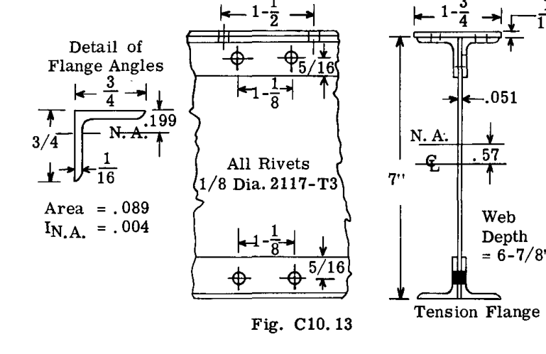

Fig. C10.13

### 解法

リベット上の荷重は、「正確な」方程式および簡略化された近似方程式の両方によって計算される。

正確な剪断流方程式は、

$$q = \frac{V}{I} \int y dA$$

である。第一のステップは、中立軸まわりの桁断面の断面二次モーメントの計算となる。曲げ荷重は、上部フランジを圧縮状態にするようなものである。

断面二次モーメントは桁断面のセンターライン軸まわりに計算され、その後、中立軸に移動される。Table C10.3に詳細な計算を示す。

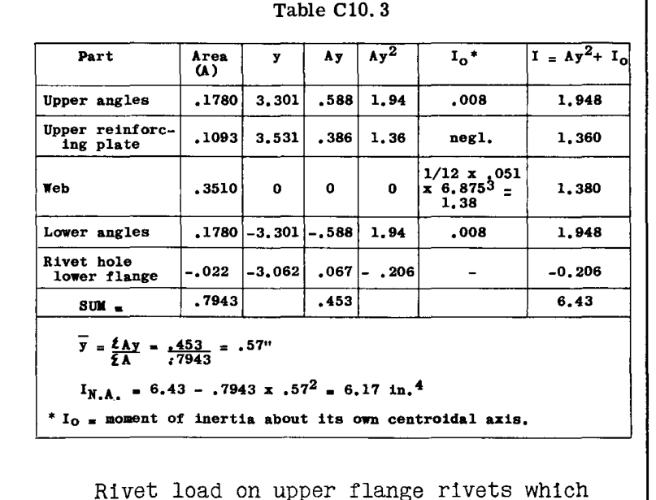

Table C10.3

アングルをウェブに取り付ける上部フランジリベット上のリベット荷重：

リベットピッチ = 1-1/8 インチ

1-1/8 インチ距離あたりの水平剪断荷重は、

$$q = 1.125 \frac{V}{I} \int y dA \quad \cdots \text{(A)}$$

に等しい。

$$\int y dA = \text{中立軸まわりのフランジ面積の一次モーメント}$$

$$\text{アングル} = 2 \times .089 \times 2.731 = .486$$

$$\text{補強板} = 1.75 \times .0625 \times 2.961 = .324$$

$$\text{合計} = .810$$

方程式 (A) に代入すると、

$$q = 1.125 \times \frac{3000}{6.17} \times .810 = 443 \text{ lb.}$$

簡略化された方程式 $q = \frac{V}{h'}$ による剪断流：

したがって、

$$q = 1.125 \times \frac{3000}{7.062} = 478 \text{ lb.}$$

となり、これは正確な表現による 443 と比較して安全側である。

ウェブは、1/8 直径 2117-T3 アルミニウム合金リベットによってアングルに取り付けられており、ダブル剪断で作用している。

第D1章から：

$$1/8 - 2117\text{-}T3 \text{ リベットのダブル剪断強度} = 2 \times 388 \times .870 = 675 \text{ lb.}$$

$$2024\text{-}T3 \text{ - .051 ウェブ板上の支圧強度} = 655 \times 1.24 = 813 \text{ lb.}$$

したがって、剪断が臨界であり、

$$\text{安全余裕 (M.S.)} = \frac{675}{443} - 1 = .52$$

となり、近似方法を使用すると安全余裕は $(675/478) - .1 = .41$ に等しくなる。

### カバープレートリベットのチェック

リベット間隔 = 1.5" で2列のリベット。

正確な方程式により、2つのリベット上の荷重は、

$$q = 1.5 \frac{V}{I} \int y dA$$

$$= 1.5 \times \frac{3000}{6.17} \times .1093 \times 2.961 = 236 \text{ lb.}$$

$$\text{ユニットあたりの荷重} = 236 / 2 = 118 \text{ lb.}$$

簡略化された公式による：

$$q = \left( \frac{V}{h'} \frac{a_{\text{plate}}}{a_{\text{flange}}} \right) 1.5 = \left( \frac{3000}{7.062} \times \frac{.1093}{.2873} \right) 1.5$$

$$= 243 \text{ lb.} = 122 \text{ lb./リベット}$$

リベットはシングル剪断状態にあり、これが臨界であり、上記のように 388 lb. に等しい。

したがって、

$$\text{安全余裕} = \frac{388}{118} - 1 = 2.28$$

である。